# Drug Screening for Muscular Dystrophy

Zachary Fralish

September 30, 2021

# **Background and Data**

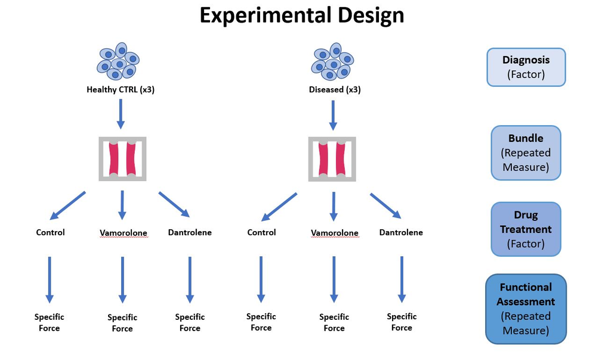

#### Quick View of the Data

```
## # A tibble: 6 x 6
##   Diagnosis Donor Experiment Treatment Bundle SpForce
##   <chr>     <chr> <chr>      <chr>      <dbl>   <dbl>
## 1 H         H1    First      CTRL           1    4.78
## 2 H         H1    First      CTRL           2    4.31
## 3 H         H1    First      CTRL           3    5.10
## 4 H         H1    First      CTRL           4    5.70
## 5 H         H1    First      CTRL           5    4.41
## 6 H         H1    First      CTRL           6    5.60
```

```
## [1] 210   6
```

# **Data Presentation**

## **Goal 1:** *Present all the data*

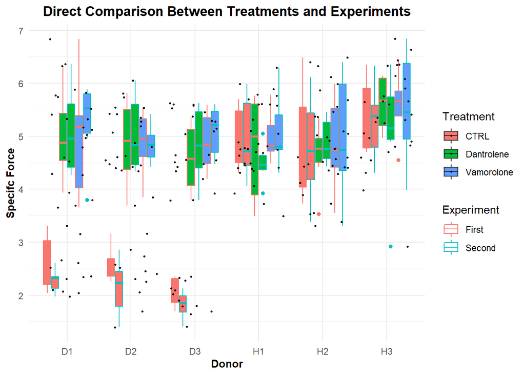

So this presents all the data. However, this graph is **very busy** , so I wanted to visualize just the important message of the data; how do the treatments affect diseased muscle vs. healthy muscle?

## **Goal 2:** *Focus the Data*

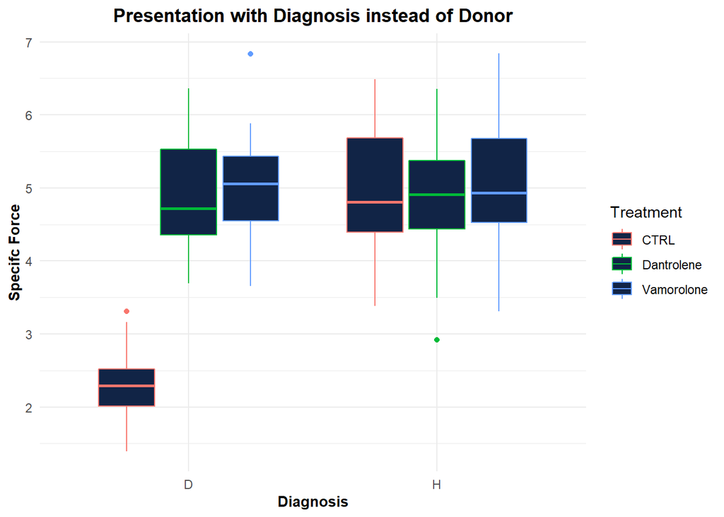

This graph more clearly depicts the takeaway message. However, considering how important treatment is to the experiment, I wanted to move that to the x-axis. Additionally, this graph does not display significance.

## **Goal 3:** *Split Graph and Run Statistics*

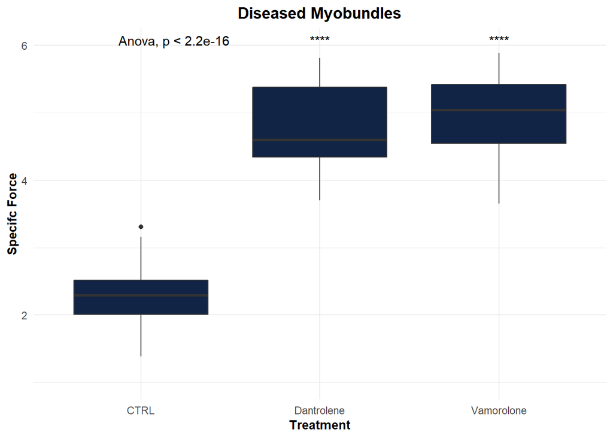

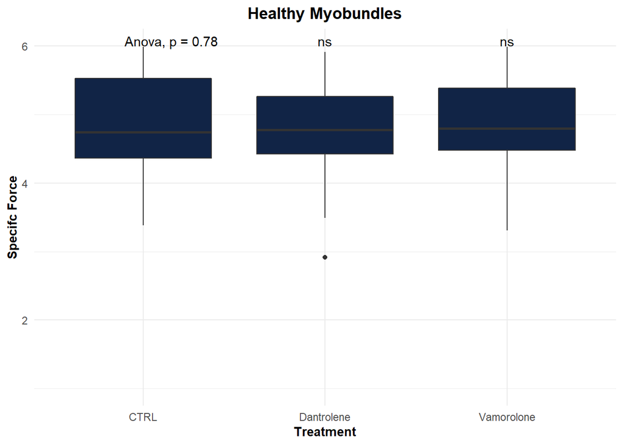

Now, this graph shows there is a statistically significant improvement in only the diseased muscle and not the healthy. However, it will be useful to directly compare these graphs side-by-side, indicate the distribution more clearly, and make the graph more aesthetically pleasing.

## **Goal 4:** *Graph Side-By-Side, Incorporate Violin Plots, and Aesthetics*

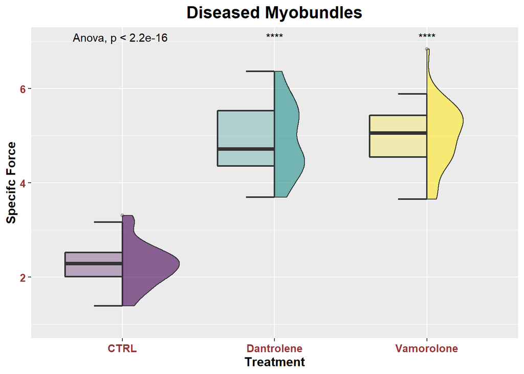

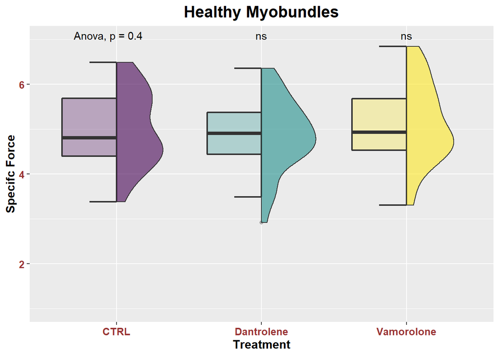

To show the data side-by-side, I added (figures-side, fig.show=“hold”, out.width=“50%”) into the header of the code. The violin plot adds an additional view of the distribution. Finally, the viridis color scheme and adjustments of labels makes the data more visually appealing.

# **Conclusions**

Ultimately, treatment with both dantolene and vamorolone augment force generation of diseased engineered muscle up to that of healthy tissues. Neither treatment augments force production in healthy tissues. This suggests that these drug treatments repair specific disease deficits instead of improving overall tissue functionality.

# **Prioritized Future Studies**

Although these treatments are promising, they only analyze function of these tissues. Next, these tissues should be structurally analyzed to see if the treatments repair structural issues associated with the membrane and/or contractile unit of the muscle in the diseased engineered muscle tissues.

# **Acknowledgements**

Thank you to Dr. Alastair Khodabukus and the Bursac lab for their efforts in setting up the myobundle system and supporting this research. Thank you to Dr. Hirschey, Akshay, Devang, and Junqi for teaching this course and being so helpful during office hours. Thank you to the creators of R, ggplot, and the tidyverse for making data visualization more accessible and the creators of font awesome for the icons. Finally thank you to my funding sources.

### Funding

[figure not shown]